# project proposal

# ============================================================================

# ============================================================================

# FIGURE 7: Histogram - Distribution of Years of Experience

# ============================================================================

# ============================================================================

# FIGURE 8: Histogram - Distribution of Average Skills

# ============================================================================

# Calculate average skill level for each job

# ============================================================================

# ============================================================================

# Display figures individually

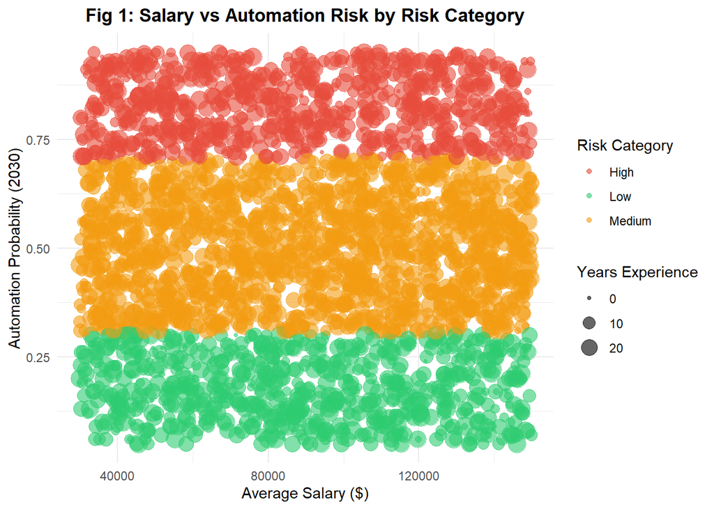

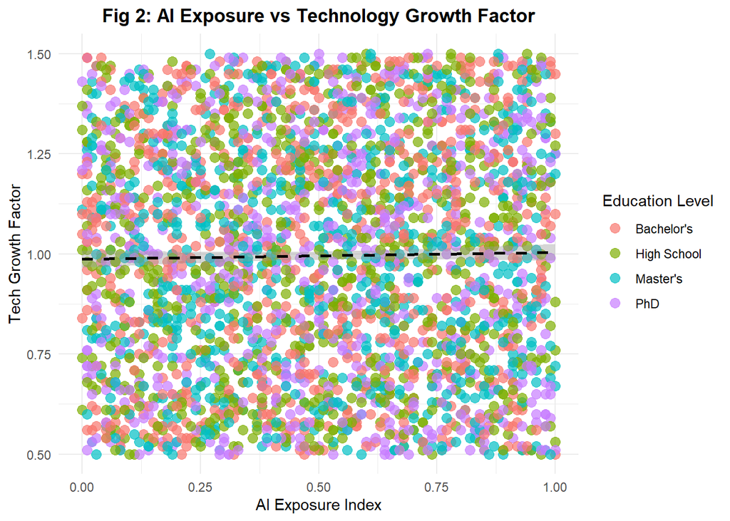

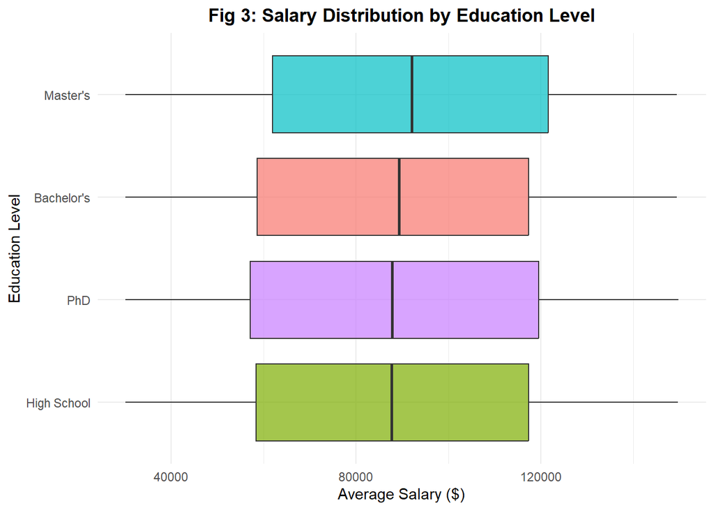

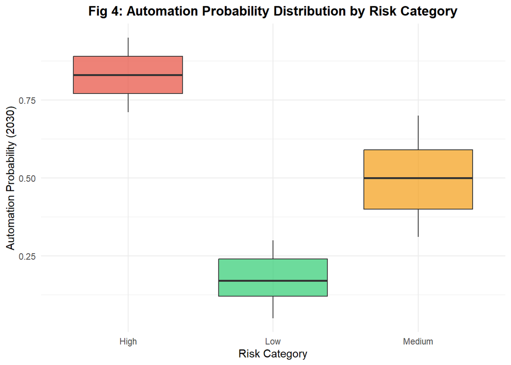

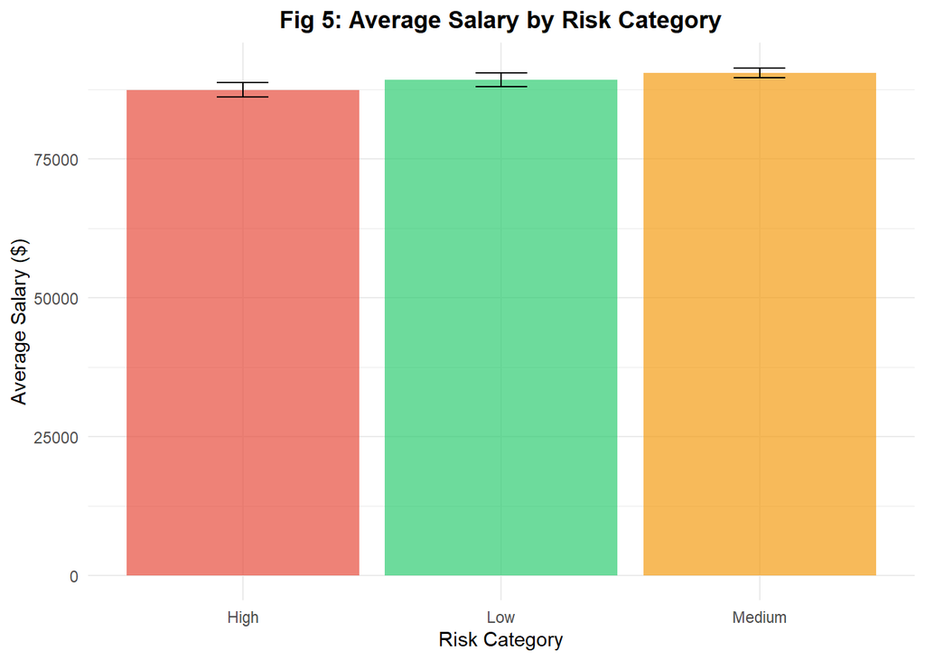

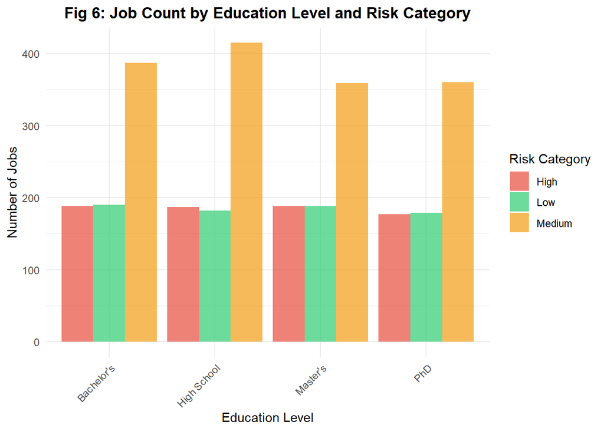

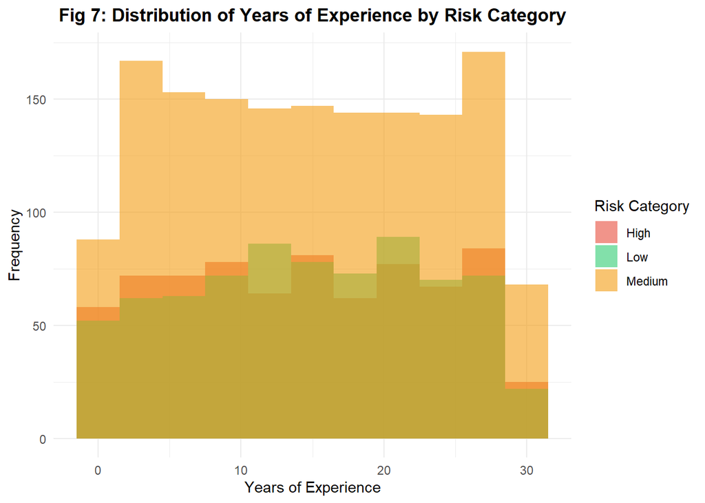

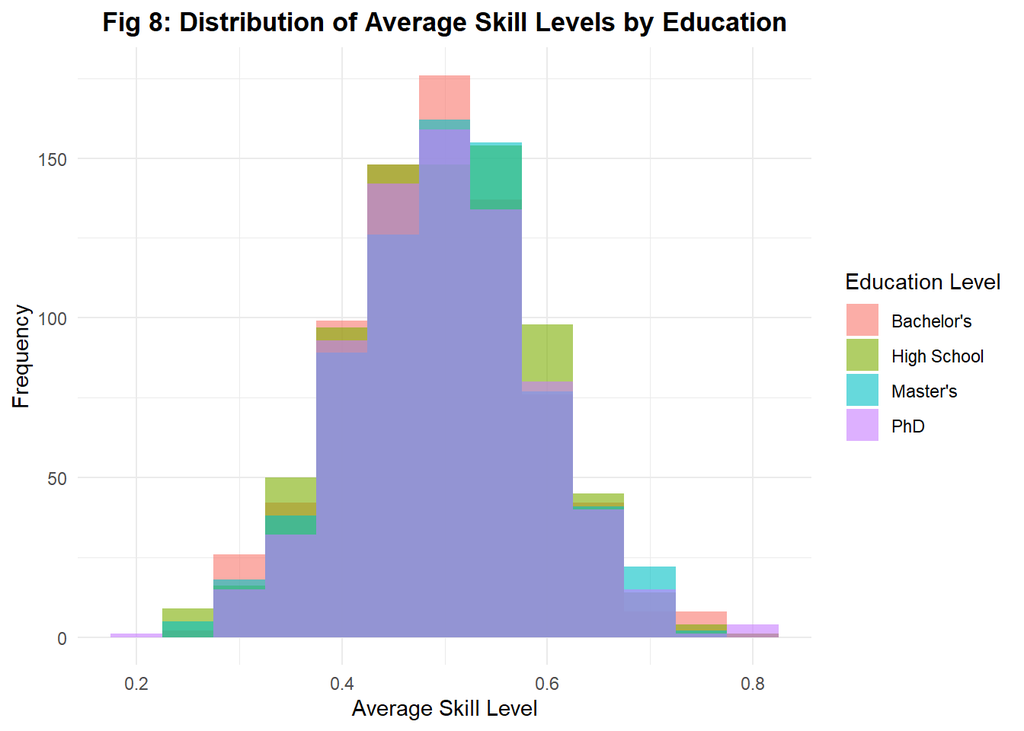

# Optional: Display all figures in a grid (requires sufficient screen space)

# grid.arrange(fig1, fig2, fig3, fig4, ncol = 2)

# grid.arrange(fig5, fig6, fig7, fig8, ncol = 2)

# ============================================================================

# ============================================================================

# Uncomment the following lines to save figures as PNG files

# ggsave(“figure1_salary_vs_automation.png”, fig1, width = 10, height = 6, dpi = 300)

# ggsave(“figure2_ai_vs_tech_growth.png”, fig2, width = 10, height = 6, dpi = 300)

# ggsave(“figure3_salary_by_education.png”, fig3, width = 10, height = 6, dpi = 300)

# ggsave(“figure4_automation_by_risk.png”, fig4, width = 10, height = 6, dpi = 300)

# ggsave(“figure5_avg_salary_by_risk.png”, fig5, width = 10, height = 6, dpi = 300)

# ggsave(“figure6_jobs_by_education_risk.png”, fig6, width = 10, height = 6, dpi = 300)

# ggsave(“figure7_experience_distribution.png”, fig7, width = 10, height = 6, dpi = 300)

# ggsave(“figure8_skill_distribution.png”, fig8, width = 10, height = 6, dpi = 300)